# Chi- Squared Testing

Nathalie Huerta

7/17/2018

# Chi- Squared Testing

## What is a Chi- Square test?

There are two types of chi- sqaure tests, using the chi- square statistic and distribution for different purposes:

The chi square stattistic, denoted as $\chi^2$, is used to examine whether distributions of categorical variables are different from one another (i.e. shows the relationship between two categorical variables). It is “a single number that tells you how much difference exists between [the] obeserved counts and the [counts] you would expect if there were no relationship at all in the population” (cite). Hence, the fomula for a chi- sqaure statistic used in the chi- square test is:

$$\chi_{c}^2 = \sum \frac{(O_i - E_i)^2}{E_i}$$
where c are the degrees of freedom, O is the observed value, and E is the expected value.

# This is just me importing data, extracting rows, and transposing the data.

```r
#loads data
chidata <- read.csv(file = "completeMerge copy.csv", header = T)
#drops 1st column b/c we don't need it
newchi <- chidata[,-c(1)]

#this code was from stackoverflow the title was "Need to convert columns to rows in R"
#need to transform the data set so the columns become the rows
#i think this transposes the data. in my opnion it did transpose the dataset but then again i could be completly wrong, we'll seee.

#creates a data frame and transposes the old data. Old data = 125 obs & 44 var -> New data = 44 obs & 125 variables
dftransposechi <- data.frame(t(newchi))

#this extracts the rows needed to build a new dataframe with only ethinicities
ethnicitychi <- dftransposechi[c("do_asian", "do_black", "do_hisp","do_white","do_other", "AsianSuspensions", "BlackSuspensions", "HispanicSuspensions", "WhiteSuspensoins", "OtherSuspensions","Expulsion_Asian",        "Expulsion_Black", "Expulsion_White","Expulsion_Hispanic","Expulsion_Other"),]

#not sure why i'm doind this but im going to transpose this dataset again
newethnicitytransposedf <- data.frame(t(ethnicitychi))
```

# This takes the sum of the colums so I can build my contingency table. A contingency table is a table of frequencies. I think there is an easier way to do this where I can I can transpose my data to get my contingency table.

```r
#need to figure out how to append the other column because in the finalized dataset that column was not merged but was there when I merged my expulsion dataset????????

#take the sum of each column to make a new dataframe. pretty sure there's a faster way of doing this
dropoutasian <- sum(as.numeric(newethnicitytransposedf$do_asian))
dropoutblack <- sum(as.numeric(newethnicitytransposedf$do_black))
dropouthisp <- sum(as.numeric(newethnicitytransposedf$do_hisp))
dropoutwhite <- sum(as.numeric(newethnicitytransposedf$do_white))
dropoutother <- sum(as.numeric(newethnicitytransposedf$do_other))
#do the same for suspension
susasian <- sum(as.numeric(newethnicitytransposedf$AsianSuspensions))
susblack <- sum(as.numeric(newethnicitytransposedf$BlackSuspensions))
sushisp <- sum(as.numeric(newethnicitytransposedf$HispanicSuspensions))
suswhite <- sum(as.numeric(newethnicitytransposedf$WhiteSuspensoins))
susother <- sum(as.numeric(newethnicitytransposedf$OtherSuspensions))
#do the same for expulsion
expulsionasian <- sum(as.numeric(newethnicitytransposedf$Expulsion_Asian))
expulsionblack <- sum(as.numeric(newethnicitytransposedf$Expulsion_Black))
expulsionhisp <- sum(as.numeric(newethnicitytransposedf$Expulsion_Hispanic))
expulsionwhite <- sum(as.numeric(newethnicitytransposedf$Expulsion_White))
expulsionother <- sum(as.numeric(newethnicitytransposedf$Expulsion_Other))
```

# This is me creating a new dataframe and me renaming the rows so my column names are the dropouts, expulsion, and suspension and my row names are the ethnicities.

```r
#install.packages("data.table")
#makes a vector with these numbers
library("data.table")
library("dplyr")
#makes a list in order to create a dataframe
dropout = c(399,788,3185,1607,659)
suspension = c(2155,4356,6341,6035, 3392)
expulsion = c(280, 518, 943,358,243)
#creates a dataframe with the above
chimatrixfortable <- data.frame(dropout, suspension, expulsion)
#renames rows
setattr(chimatrixfortable, "row.names", c("Asian", "Black", "Hispanic","White", "Other"))
```

# This is me making ballonplots. I’m really not sure what they’re saying but I think it tells us where the most students are and there ethinicities as well as if they dropped out, got suspended, or expelled. I think it just serves as a summary of the data we have.

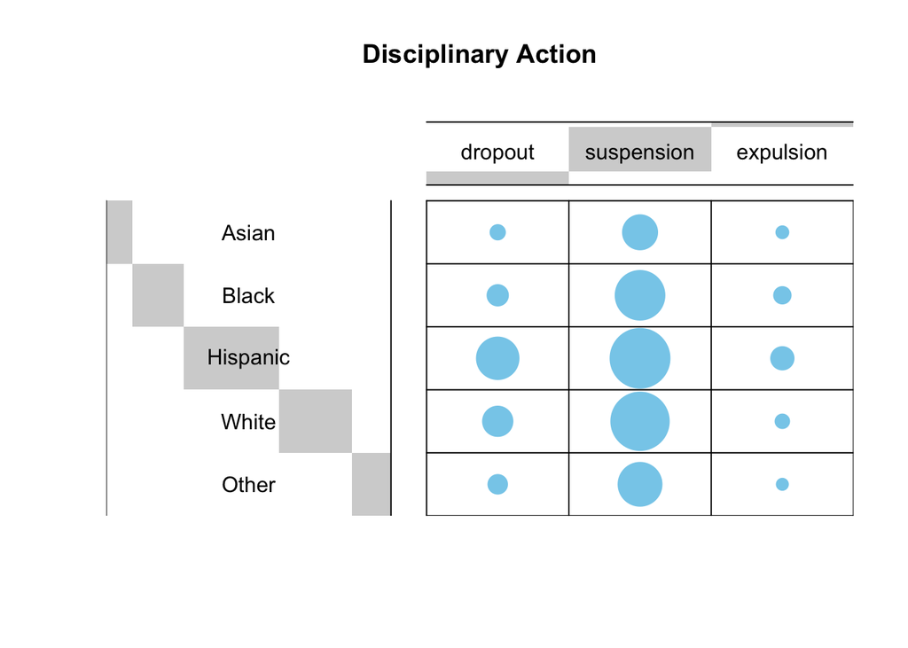

```r
#this code was obtained from Statistical tools for high-throughput data analysis
#install.packages("gplots")
library(gplots)
library(ggplot2)
# convert the data as a table
#this code creates a table in
dt <- as.table(as.matrix(chimatrixfortable))
# Graphs the new table dt
balloonplot(t(dt), main ="Disciplinary Action", xlab ="", ylab="",
            label = FALSE, show.margins = FALSE)
```

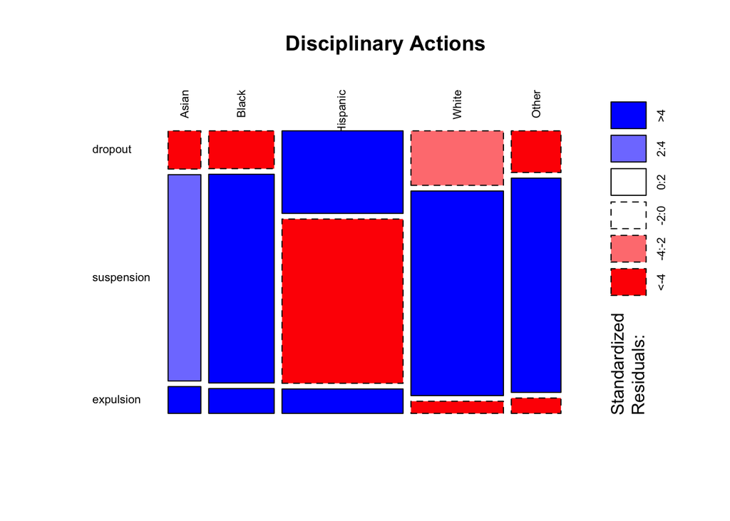

```r
#need to look into how to interpret

library("graphics")
mosaicplot(dt, shade = TRUE, las=2,
           main = "Disciplinary Actions")
```

# This computes the chi sqaure test.

```r
# computing the chi- square test
chisq <- chisq.test(chimatrixfortable)
chisq
```

```
##
##  Pearson's Chi-squared test
##
## data:  chimatrixfortable
## X-squared = 1151.4, df = 8, p-value < 2.2e-16
```

```r
#computed the observed counts
chisq$observed
```

```
##          dropout suspension expulsion
## Asian        399       2155       280
## Black        788       4356       518
## Hispanic    3185       6341       943
## White       1607       6035       358
## Other        659       3392       243
```

```r
#computes the expected counts and rounds to 2 decimal points
round(chisq$expected,2)
```

```
##          dropout suspension expulsion
## Asian     601.81    2019.86    212.33
## Black    1202.35    4035.44    424.21
## Hispanic 2223.14    7461.49    784.36
## White    1698.84    5701.78    599.38
## Other     911.85    3060.43    321.72
```

```r
#prints out the residuals for the chi square
round(chisq$residuals, 3)
```

```
##          dropout suspension expulsion
## Asian     -8.267      3.007     4.644
## Black    -11.950      5.046     4.554
## Hispanic  20.400    -12.972     5.664
## White     -2.228      4.413    -9.859
## Other     -8.373      5.994    -4.389
```

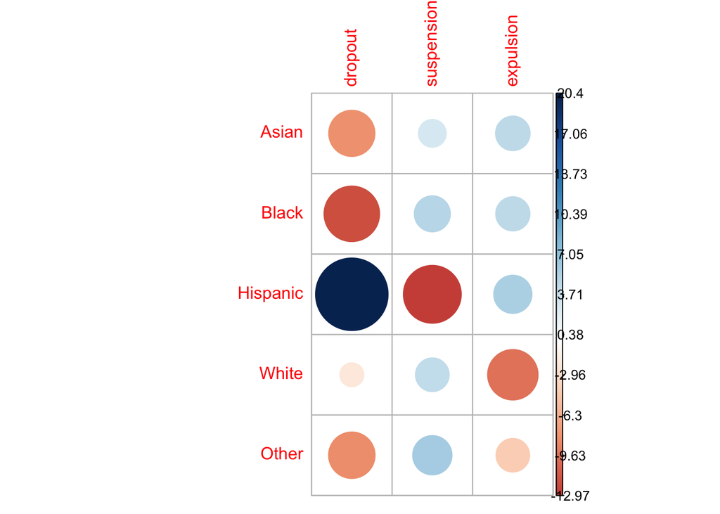

```r
#visualization of the residuals
library(corrplot)
corrplot(chisq$residuals, is.cor = FALSE)
```

```r
# Contibution in percentage (%)
contrib <- 100*chisq$residuals^2/chisq$statistic
round(contrib, 3)
```

```
##          dropout suspension expulsion
## Asian      5.936      0.785     1.873
## Black     12.402      2.212     1.801
## Hispanic  36.143     14.614     2.787
## White      0.431      1.691     8.443
## Other      6.090      3.120     1.673
```

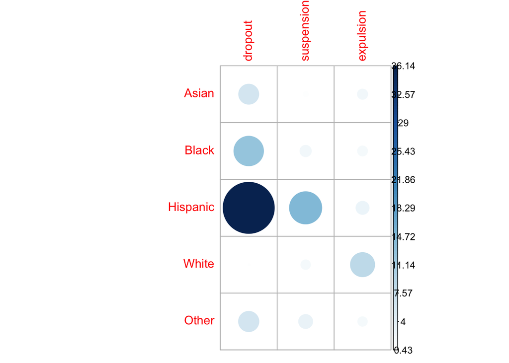

```r
# Visualize the contribution
corrplot(contrib, is.cor = FALSE)
```